# Human Judgment in Data

POLS 2140: Introduction to Political Analysis

Dr. Sarah Dreier

## Reading Prompt

In the Silberzahn et. al. article, “Many Analysts, One Dataset,” what was the *substantive* research question the research teams were answering? What was one thing you learned about how human judgment shapes statistical outcomes (just try your best to answer this question!)?

## Announcements

- **Data News sign-up:** 6 outstanding; we will assign for you on Saturday.
- **Weekly Assignment** posted today!

## Data News Presentations

- **Kennedy Brown** — [Dissatisfaction with Democracy Remains Widespread in Many Nations](https://www.pewresearch.org/short-reads/2025/06/30/dissatisfaction-with-democracy-remains-widespread-in-many-nations/) (Pew Research Center)
- **Zuriel Castillo** — [AI Chatbots Political Opinions Study](https://www.nytimes.com/2025/12/05/well/ai-chatbots-political-opinions-study.html) (*New York Times*)

# What is Data?

What is **data?**

What are some examples of data used to study **politics** and/or the **social world?**

What data did the research in your blog post (from Tuesday) use? Did the researchers generate the data themselves or adopt it from somewhere else?

What data did the researchers in the Silberzahn article use?

Data represents how we **measure concepts of interest.**

[figure not shown]

[figure not shown]

# All analyses involve human judgements

## All analyses involve (hopefully reasonable!) human judgements / decisions

Human judgement is involved at every stage of the research pipeline, including:

- The **questions** we ask…
- How we **produce** the data
- How we **analyze** the data

## The **questions** we ask

[figure not shown]

## How we **produce** the data…

> “The context of data — why it was collected, how it was collected, and how it was transformed — is always relevant. There is, then, no such thing as context-free data…” ([Barrowman](https://www.thenewatlantis.com/publications/why-data-is-never-raw))

**Some (of many) questions to ask about our data:**

- Are we measuring what we think we’re measuring?
- Would reasonable people approach the task differently and defensibly?
- Would different approaches to measuring a given concept give us a different result?
- Do people have incentives to lie, distort, hide, or refuse to answer?
- Who is excluded/under-represented?

[figure not shown]

Our lived experiences shape how we approach our data.

“But experts and non-experts alike encounter the world not merely through sense experiences but **through frameworks of understanding shaped by numerous factors including theories, values, norms, and faith.** It may be tempting to suppose that this context can simply be set aside. But assumptions, when not made explicit, do not simply cease to exist. Rather, they influence the direction of inquiry, the choice of measurements, the way the data is collected and transformed, and the conclusions that are drawn.”

## Ex from Natural Language Processing: Human bias in “pretraining” data

**Large Language Models** are used to **classify, predict,** or **generate** large amounts of text (e.g., predicting what question you’ll google, or **generating** text via ChatGPT).

LLMs are **“pretrained”** on huge swaths of human-written text. The biases reflected in these texts get baked into the language models.

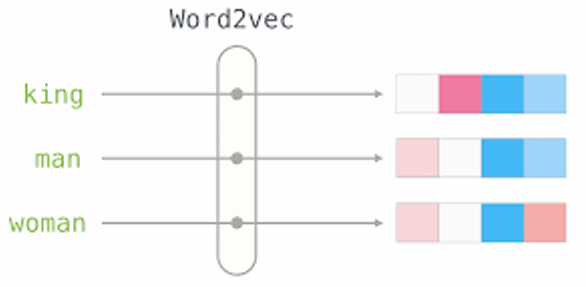

Human judgement?

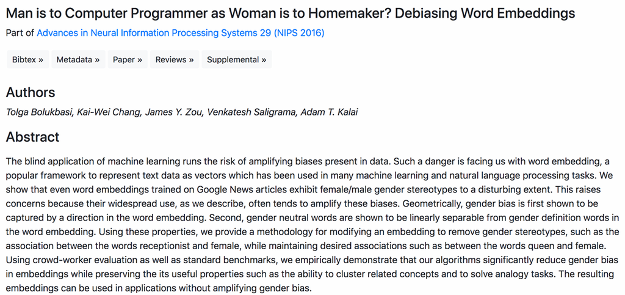

## How we **analyze** the data…

Case Study: “Many Analysts, One Data Set: Making Transparent How Variations in Analytic Choices Affect Results” (Silberzahn et al., 2018).

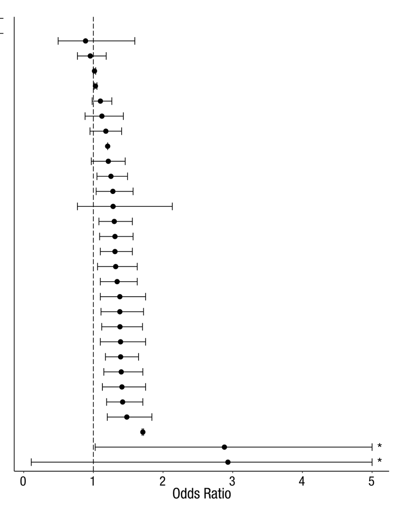

Each team’s estimated effect (odds ratio) of player skin tone on red cards awarded, with 95% CIs; dashed line = no effect (OR = 1). Source: Silberzahn et al. (2018, Figure 2, p. 346).

**What caused this variation?**

## Different statistical models

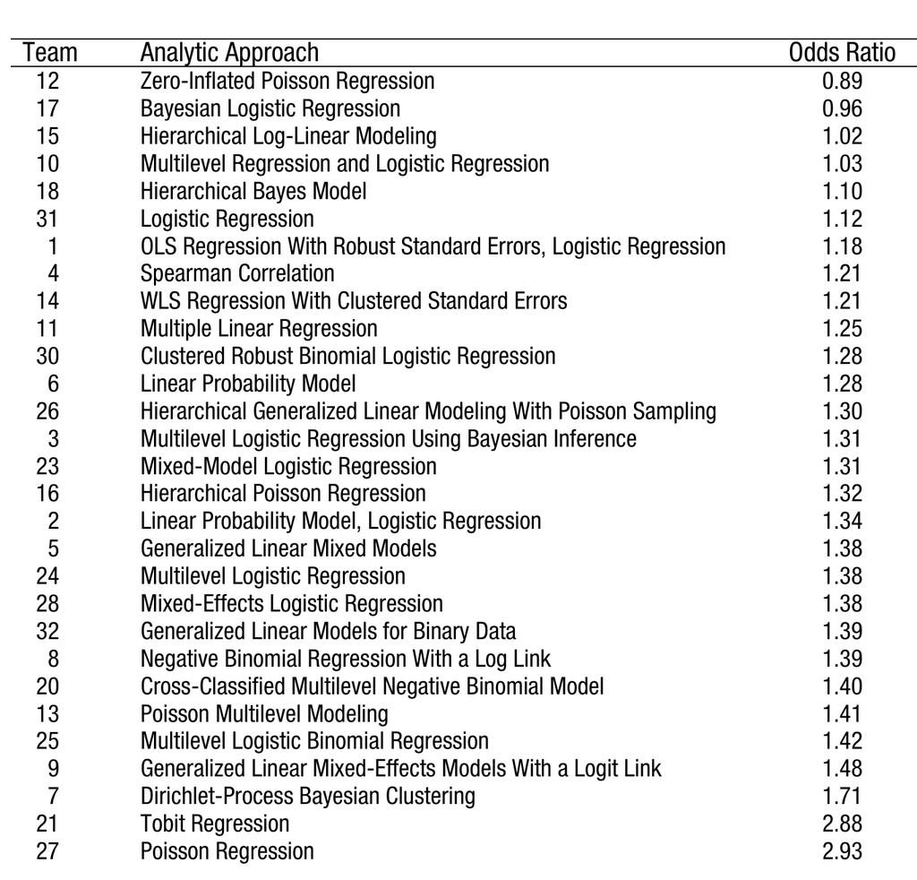

The analytic approach behind each row of the plot, and the odds ratio it produced — ordered smallest to largest. Source: Silberzahn et al. (2018, Figure 2, p. 346).

## Different covariate combinations

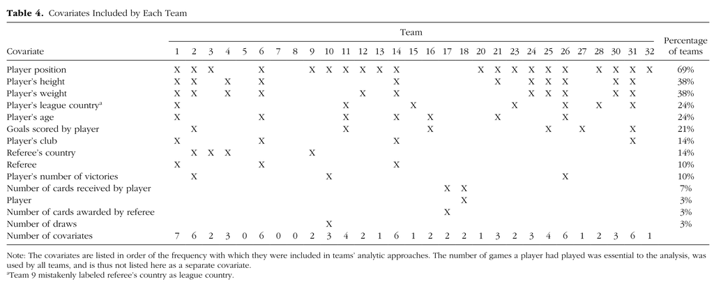

Covariates each team chose to control for — 21 different combinations across 29 teams. Source: Silberzahn et al. (2018, Table 4, p. 345).

# For more detail (not covered in class), see slides 18-21

## Judgment Call #1: Turning “skin tone” into a number

- Before anyone ran a single statistical test, someone had to decide **how to measure** skin tone in the first place
- Two independent raters looked at photos of 1,586 players and scored each one on a 5-point scale, from very light to very dark
- That scale was then rescaled to a single 0–1 “skin tone” variable — the number every team’s analysis was built on
- A judgment call is baked into the data *before* a single model is even run

## EX from [AfroBarometer](https://www.afrobarometer.org/)

[figure not shown]

**Would you like having people from this group as neighbors?**

- People from a different region
- People from other ethnic groups
- LGB people
- Immigrants or foreign workers
- People who support a different political party

**Response Options:**

1. Strongly dislike
2. Somewhat dislike
3. Would not care
4. Somewhat like
5. Strongly like
6. DK/Refuse

What answer indicates the greatest degree of tolerance?

## So does this mean we dismiss all data out-of-hand?

Instead actively consider:

- How reasonable people would make different decisions, and how that might change the analysis outcomes
- Possible sources of bias and/or harmful downstream uses. Look for them, name them, think through what this means for your conclusions.

## References

Silberzahn, R., Uhlmann, E. L., Martin, D. P., Anselmi, P., Aust, F., Awtrey, E., Bahník, Š., Bai, F., Bannard, C., Bonnier, E., Carlsson, R., Cheung, F., Christensen, G., Clay, R., Craig, M. A., Dalla Rosa, A., Dam, L., Evans, M. H., Flores Cervantes, I., … Nosek, B. A. (2018). Many analysts, one data set: Making transparent how variations in analytic choices affect results. *Advances in Methods and Practices in Psychological Science*, *1*(3), 337–356. https://doi.org/10.1177/2515245917747646